# Average Treatment Effects and Heterogeneous Treatment Effects

Prof. Susan Athey

Stanford University

PhD student, Nicolaj Naargaard Mahlbach

Aarhus University

January 7, 2018

Abstract

The focus of this tutorial is on heterogeneous treatment effects in randomized experiments. The techniques include LASSO, post-selection OLS, honest causal tree, and causal forest. We focus on machine learning methods as an alternative to standard microeconometric methods.

To recap, the economic question at hand concerns the effect of social pressure on voter turnout and this builds on a randomized controlled trial (RCT) by Gerber, Green, and Larimer (2008) ([for more details, see article](http://isps.yale.edu/sites/default/files/publication/2012/12/ISPS08-001.pdf)). As the first tutorial introduces the specific data set, we will not devote time to discuss it here.

In the following, we load all the necessary packages.

```r
knitr::opts_chunk$set(echo=TRUE, warning=FALSE, message=FALSE, comment=NA)

# Load all packages needed to execute the job
# If the packages are not installed, write
# install.packages("<name of package>")

#CRAN Packages
library(devtools)
library(ggplot2)    # plot
library(devtools)   # install from GitHub
library(dplyr)      # tables
library(glmnet)     # lasso

library(grf)        # generalized random forest

#Non-CRAN Packages
# Need to install from github, uncomment next lines, and requires package devtools
#install_github('susanathey/causalTree')
#install_github('swager/randomForestCI')
#install_github('swager/balanceHD')
# if you have an error in installing from github, you may need developer tools (rtools on Windows)
library(causalTree)
library(randomForestCI)
library(balanceHD)  # balance residuals
```

We load the data as a .csv file.

```r
# Clear RStudio
rm(list = ls())

# Start timer
ptm <- proc.time()

# Set seed
set.seed(2045)

# Loading data
filename <- 'socialneighbor.csv'

# Creating raw data
data_raw <- read.csv(filename)

# Restricting the sample size
n_obs <- 35000 # Reduce for testing; choosing a sample size of 5,000 runs in few minutes
data_raw <- data_raw[sample(nrow(data_raw), n_obs), ]

# Rename treatment variable
names(data_raw)[names(data_raw) == "treat_neighbors"] <- "W"

# Rename outcome variable, i.e. voted in the August 2006 primary
names(data_raw)[names(data_raw) == "outcome_voted"] <- "Y"

# Extract covariates
covariates_names <- c("sex", "yob", "city", "hh_size", "totalpopulation_estimate",
                      "percent_male", "median_age", "percent_62yearsandover",
                      "percent_white", "percent_black", "percent_asian", "median_income",
                      "employ_20to64", "highschool", "bach_orhigher","percent_hispanicorlatino")

# Create data frame of covariates
covariates_raw <- data_raw[covariates_names]

# Scale covariates
covariates_scaled <- scale(covariates_raw)

# Extract indicator variables
dummy_names <- c("g2000", "g2002", "p2000", "p2002", "p2004")

# Create data frame ofindicator variables
dummy_raw <- data_raw[dummy_names]

# Combine data into one data frame
data_scaled <- data.frame(Y = data_raw[["Y"]],
                          W = data_raw[["W"]],
                          dummy_raw,
                          covariates_scaled)

# Omit NA's
data_complete <- na.omit(data_scaled)

# Cleaning work space
rm(list = setdiff(ls(), c("data_complete", "ptm")))
```

Next, we implement the decision rule, turning the randomized experiment into an observational study by randomly dropping certain candidate observations. Again, this is fully explained in our first tutorial.

```r
## Modify data set
# Creating modified data set
data_modified <- data_complete

# Maximal percentage of candidates to be randomly removed
remove_pct <- 0.80

## Introducing bias by systematically deleting some obsercations
# Voting history
# Remove control with recent voting history
# Count the potential candidates to be removed
size_1 <- sum(data_modified$W == 0 & data_modified$p2004 == 1 & data_modified$p2000 == 1 & data_modified$p2002 == 1)

data_modified <- data_modified[-sample(which(data_modified$W == 0 &
                                             data_modified$p2000 == 1 &
                                             data_modified$p2002 == 1 &
                                             data_modified$p2004 == 1),
                                       size = remove_pct * size_1), ]

# Remove treated with no recent voting history
# Count the potential candidates to be removed
size_2 <- sum(data_modified$W == 1 & data_modified$p2004 == 0 & data_modified$p2000 == 0 & data_modified$p2002 == 0)

data_modified <- data_modified[-sample(which(data_modified$W == 1 &
                                             data_modified$p2000 == 0 &
                                             data_modified$p2002 == 0 &
                                             data_modified$p2004 == 0),
                                       size = remove_pct * size_2), ]
```

Next, we will split the data into a training sample and a testing sample. This is a common approach in the machine learning literature to assess the ability to generalize out-of-sample. We allow the training proportion to be set dynamically by the researcher, but common practice is in the interval $\left(0.67, 0.9\right)$.

```r
# Set up fraction for training/testing split
train_pct <- 0.9

# Create random sample index for training
train_index <- sample(nrow(data_modified), size = round(nrow(data_modified) * train_pct), replace = FALSE)

# Construct training and testing data as data frames with both Y, W, and covariates
train <- data_modified[train_index, ]
test <- data_modified[-train_index, ]

# Construct reponse variable as a single-column matrix
Y_train <- as.matrix(train$Y, ncol = 1)
Y_test <- as.matrix(test$Y, ncol = 1)

# Construct treatment variable as a single-column matrix
W_train <- as.matrix(train$W, ncol = 1)
W_test <- as.matrix(test$W, ncol = 1)

# Construct covariates as a matrix
X_train <- as.matrix(subset(train, select = c(setdiff(colnames(train), c("Y", "W")))))
X_test <- as.matrix(subset(test, select = c(setdiff(colnames(test), c("Y", "W")))))
```

We begin by the propensity forest algorithm. The propensity forest is similar to causal forest, but whereas causal forest uses the actual outcome variable in the tree building phase, the propensity forest splits the trees using the covariates and treatment vector. Specifically, we build a tree with $W \sim X$, and then estimate the treatment effects within each leaf, which conceptually corresponds to propensity matching. The overall purpose of causal forest is to estimate the effect of the treatment at the leaves of the trees, and the same applies to propensity forest. This method is similar to propensity score matching.

```r
# List covariates in the linear model
sumx <- paste(c(colnames(X_train)) , collapse = " + ")

# Get formula
pf_fml <- as.formula(paste("Y", sumx, sep = " ~ "))

# Settings for Propensity Forest (PS)
# Minimum number of observations for treated and control cases in one leaf node
node_size <- 25

# Number of trees to be built in the causal forest
num_trees <- 2000 # make 2000

# Sample size used to build each tree in the forest (sampled randomly with replacement)
sample_size <- floor(nrow(train) / 2)

# Number of covariates randomly sampled to build each tree in the forest
covar_size <- floor(ncol(X_train) / 3)

# Train propensity forest model
pf <- propensityForest(formula = pf_fml,
                       data = train,
                       treatment = W_train,
                       split.Bucket = FALSE,
                       sample.size.total = sample_size,
                       nodesize = node_size,
                       num.trees = num_trees,
                       mtry = covar_size,
                       ncolx = ncol(X_train),
                       ncov_sample = covar_size)

# Predict in test data
pf_pred_test <- predict(pf, newdata = test)
```

Next, we turn to the generalized random forest package. We try it first without residualizing, but just run with Y, W, X. Second, we try it after residualizing first, which is more important for an observational study than for a randomized experiment, but generally brings gains in both places. To residualize, you can use a standard random forest or lasso prediction package to estimate the conditional means of the treatment, the control outcomes, and the treated outcomes. Use grf’s causal forest routine on the residuals. A LASSO might be preferred if there are strong linear effects of covariates on outcomes.

We first estimate a causal forest without residualizing first. This is determined by the option *precompute.nuisance*, which we set to *FALSE*.

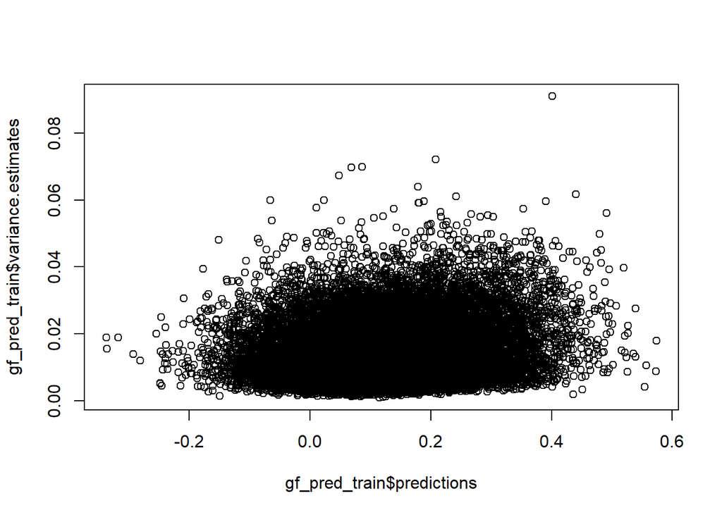

```r
# Settings for Gradient Forest (GS)
# Number of trees grown in the forest
num_trees <- 2000 # make 2000

# The forest will grow ci.group.size trees on each subsample.
ci_size <- 4

# First run regression forests to estimate y(x) = E[Y|X=x] and w(x) = E[W|X=x], and then run a causal forest on the residuals?
pre_comp <- FALSE

# Train gradient forest model
gf <- causal_forest(X = X_train,
                    Y = Y_train,
                    W = W_train,
                    num.trees = num_trees,
                    ci.group.size = ci_size,
                    precompute.nuisance = pre_comp)

# Predict in test data
gf_pred_test <- predict(gf, newdata = X_test, estimate.variance = TRUE)

# Predict in training data
gf_pred_train <- predict(gf, newdata = X_train, estimate.variance = TRUE)


# Variance plot
plot(gf_pred_train$predictions, gf_pred_train$variance.estimates)
```

Next, we residualize first. Note that we can use LASSO or random forest prediction, and we choose to stick with random forest here. Essentially, we estimate the conditional means of the treatment and the response. After taking first difference between the actual treatment and the estimated treatment and likewise for the response, we use causal forest to estimate the treatment effects by specifying the covariates and the residualized response and treatment. Note that also if we set precompute.nuisance = TRUE, the routine would do this for us.

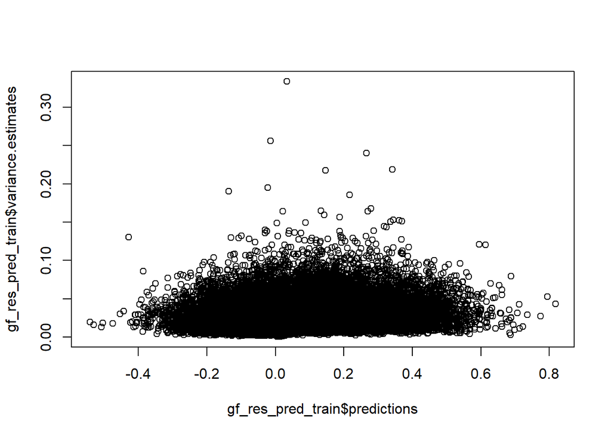

```r
# Estimate the conditional means of the treatment
W_rf <- regression_forest(X = X_train,
                          Y = W_train,
                          num.trees = num_trees,
                          ci.group.size = ci_size)

# Predict residuals
W_res <- W_train - predict(W_rf, newdata = X_train)$predictions

# Estimate the conditional means of the response
Y_rf <- regression_forest(X = X_train,
                          Y = Y_train,
                          num.trees = num_trees,
                          ci.group.size = ci_size)

# Predict residuals
Y_res <- Y_train - predict(Y_rf, newdata = X_train)$predictions

# Causal forest on residuals
# Train gradient forest model
gf_res <- causal_forest(X = X_train,
                        Y = Y_res,
                        W = W_res,
                        num.trees = num_trees,
                        ci.group.size = ci_size,
                        precompute.nuisance = pre_comp)

# Predict in test data
gf_res_pred_test <- predict(gf_res, newdata = X_test, estimate.variance = TRUE)

# Predict in training data
gf_res_pred_train <- predict(gf_res, newdata = X_train, estimate.variance = TRUE)

# Variance plot
plot(gf_res_pred_train$predictions, gf_res_pred_train$variance.estimates)
```

# Part 2: Heterogeneous Treatment Effects in Randomized Experiments

Now we return to the un-altered randomized experiment. Use random sampling to divide the data set into three equal size data sets, call them A, B, and C

```r
# Set up fraction for main split
pct_main <- 2/3

# Create random sample index for main split
index_main <- sample(nrow(data_complete), size = round(nrow(data_complete) * pct_main), replace = FALSE)

# Construct data frame with both Y, W, and covariates
data_main <- data_complete[index_main, ]
data_C <- data_complete[-index_main, ]

# Set up fraction for causal split
pct_causal <- 1/2

# Create random sample index for causal split
index_causal <- sample(nrow(data_main), size = round(nrow(data_main) * pct_causal), replace = FALSE)

# Construct data frame with both Y, W, and covariates
data_A <- data_main[index_causal, ]
data_B <- data_main[-index_causal, ]

# Construct reponse variable as a single-column matrix
Y_A <- as.matrix(data_A$Y, ncol = 1)
Y_B <- as.matrix(data_B$Y, ncol = 1)
Y_C <- as.matrix(data_C$Y, ncol = 1)

# Construct treatment variable as a single-column matrix
W_A <- as.matrix(data_A$W, ncol = 1)
W_B <- as.matrix(data_B$W, ncol = 1)
W_C <- as.matrix(data_C$W, ncol = 1)

# Construct covariates as a matrix
X_A <- as.matrix(subset(data_A, select = c(setdiff(colnames(data_A), c("Y", "W")))))
X_B <- as.matrix(subset(data_B, select = c(setdiff(colnames(data_B), c("Y", "W")))))
X_C <- as.matrix(subset(data_C, select = c(setdiff(colnames(data_C), c("Y", "W")))))

# Clear workspace
rm(pct_main, pct_causal, index_main, index_causal, data_main, data_complete)
```

As we will compare performance of the different methods based on out-of-sample MSE, we will subsequently use sub-sample A as training data, sample B as estimation data (when needed) and sub-sample C as testing data, unless otherwise stated.

## Problem 2

We start out be running LASSO to estimate the heterogeneous effects. For intuition about LASSO, see the first tutorial. Note that we create copies of the sub-samples and alter the treatment variables to be only $0$ or $1$, respectively, and use this when making predictions. This is a practical trick for estimating E[Y|X=x,W=1]-E[Y|X=x,W=0].

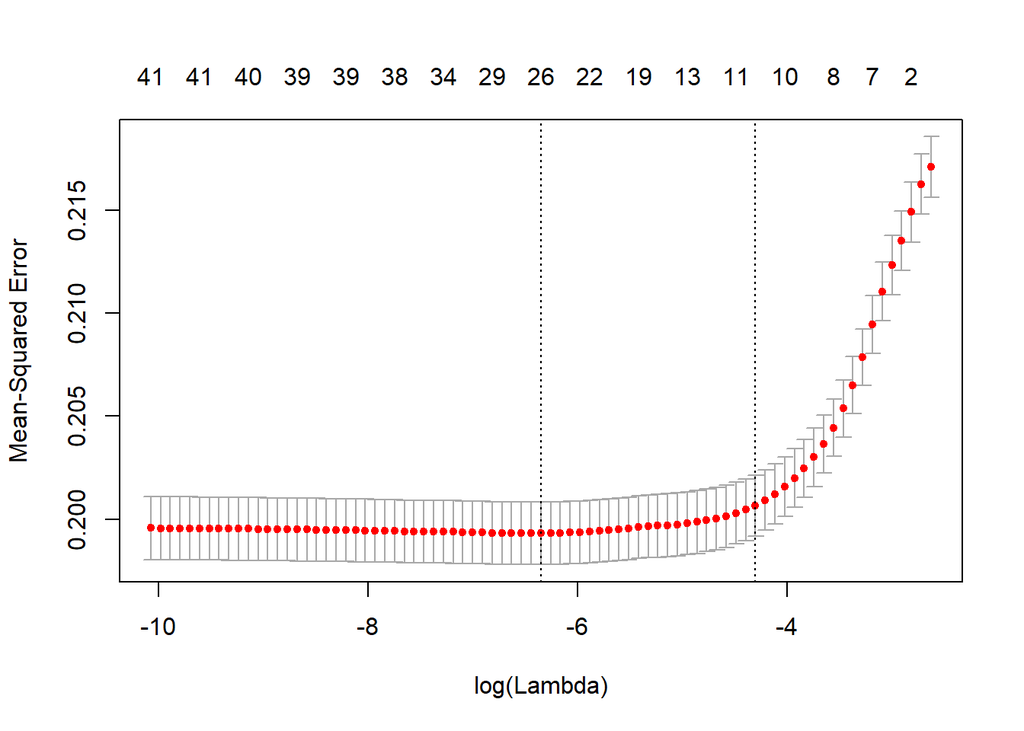

```r
# Re-create data frame C and set treatment W to 0 for all observations
data_C_W0 <- data_C
data_C_W0$W <- 0

# Re-create data frame C and set treatment W to 1 for all observations
data_C_W1 <- data_C
data_C_W1$W <- 1

# Get formula
sumx <- paste(c(colnames(X_A)) , collapse = " + ")
linear_het <- as.formula(paste("Y", paste("W * (", sumx, ") ", sep = ""), sep = " ~ "))

# Get model matrix used in the glmnet package
train_A <- model.matrix(object = linear_het, data = data_A)[, -1]
test_C_W0 <- model.matrix(object = linear_het, data = data_C_W0)[, -1]
test_C_W1 <- model.matrix(object = linear_het, data = data_C_W1)[, -1]

# Train lasso model using cross-validation
lasso_linear_A <- cv.glmnet(x = train_A,
                            y = Y_A,
                            family = 'gaussian')

# Make predictions for W = 0 and W = 1 using cross-validated penalty (\lambda)
pred_lasso_W0 <- predict(lasso_linear_A, newx = test_C_W0, s = lasso_linear_A$lambda.1se)
pred_lasso_W1 <- predict(lasso_linear_A, newx = test_C_W1, s = lasso_linear_A$lambda.1se)

# Compute heterogeneous treatment effects
pred_lasso_C <- pred_lasso_W1 - pred_lasso_W0

# Plot MSE vs. shrinkage parameter
plot(lasso_linear_A)
```

Then, we turn to post-selection OLS. The *post-selection* refers to the first part where we select the relevant variables by LASSO. Now, we run OLS only on the relevant variables selected by LASSO.

```r
# List of non-zero variables
coef <- predict(lasso_linear_A,
                s = lasso_linear_A$lambda.1se,
                type = "nonzero")

# Index the column names of the matrix in order to index the selected variables
colnames <- colnames(train_A)
selected_vars <- colnames[unlist(coef)]

# Get formula for non-zero coefficients
post_selec_ols_fml <- as.formula(paste("Y", paste(append(selected_vars, "W"), collapse = " + "), sep = " ~ "))

# Train post-selection OLS model using non-zero coefficients and data A
post_selec_ols_A <- lm(formula = post_selec_ols_fml,
                       data = data_A)

# Make predictions for W = 0 and W = 1
pred_ols_W0_C <- predict(post_selec_ols_A, newdata = data_C_W0)
pred_ols_W1_C <- predict(post_selec_ols_A, newdata = data_C_W1)

# Compute heterogeneous treatment effects
pred_post_selec_ols_C <- pred_ols_W1_C - pred_ols_W0_C
```

We can also compare the coefficient estimates across sub-samples. How do the coefficents compare between those where the same data were used to select the specification and estimate parameters, and those where different data were used? Why do you think that happens? Typically, sample splitting is very important in practice, and it is not recommended to use the same data to select the model and to estimate parameters unless you can establish that it works (by showing that sample splitting gives similar answers.) You would generally get tighter standard errors by using all of your data to both select the model and estimate parameters, but also the coefficients are usually biased if you do that.

```r
post_selec_ols_B <- lm(formula = post_selec_ols_fml,
                       data = data_B)
post_selec_ols_C <- lm(formula = post_selec_ols_fml,
                       data = data_C)


summary(post_selec_ols_A)
```

```
Call:
lm(formula = post_selec_ols_fml, data = data_A)

Residuals:
    Min      1Q  Median      3Q     Max
-0.7489 -0.3344 -0.2153  0.5319  0.9900

Coefficients:
               Estimate Std. Error t value Pr(>|t|)
(Intercept)    0.108636   0.012495   8.694  < 2e-16 ***
W              0.072808   0.028510   2.554   0.0107 *
g2002          0.064321   0.012954   4.965 6.96e-07 ***
p2000          0.083902   0.009539   8.795  < 2e-16 ***
p2002          0.119408   0.008738  13.666  < 2e-16 ***
p2004          0.159872   0.009303  17.185  < 2e-16 ***
yob           -0.025070   0.004384  -5.719 1.10e-08 ***
city           0.047864   0.004143  11.553  < 2e-16 ***
employ_20to64 -0.017732   0.004251  -4.171 3.06e-05 ***
W:g2002        0.020182   0.029731   0.679   0.4973
W:p2004        0.033701   0.022284   1.512   0.1305
---
Signif. codes:  0 '***' 0.001 '**' 0.01 '*' 0.05 '.' 0.1 ' ' 1

Residual standard error: 0.4464 on 11655 degrees of freedom
Multiple R-squared:  0.08318,   Adjusted R-squared:  0.08239
F-statistic: 105.7 on 10 and 11655 DF,  p-value: < 2.2e-16
```

```r
summary(post_selec_ols_B)
```

```
Call:
lm(formula = post_selec_ols_fml, data = data_B)

Residuals:
    Min      1Q  Median      3Q     Max
-0.7207 -0.3385 -0.2245  0.5549  0.9597

Coefficients:
               Estimate Std. Error t value Pr(>|t|)
(Intercept)    0.126911   0.012134  10.459  < 2e-16 ***
W              0.022778   0.027534   0.827    0.408
g2002          0.063955   0.012640   5.060 4.26e-07 ***
p2000          0.078813   0.009483   8.311  < 2e-16 ***
p2002          0.114128   0.008823  12.935  < 2e-16 ***
p2004          0.143944   0.009381  15.345  < 2e-16 ***
yob           -0.029000   0.004330  -6.697 2.23e-11 ***
city           0.032937   0.004261   7.731 1.16e-14 ***
employ_20to64 -0.003889   0.004216  -0.922    0.356
W:g2002        0.024808   0.029017   0.855    0.393
W:p2004        0.038620   0.022561   1.712    0.087 .
---
Signif. codes:  0 '***' 0.001 '**' 0.01 '*' 0.05 '.' 0.1 ' ' 1

Residual standard error: 0.4503 on 11656 degrees of freedom
Multiple R-squared:  0.06638,   Adjusted R-squared:  0.06558
F-statistic: 82.88 on 10 and 11656 DF,  p-value: < 2.2e-16
```

```r
summary(post_selec_ols_C)
```

```
Call:
lm(formula = post_selec_ols_fml, data = data_C)

Residuals:
    Min      1Q  Median      3Q     Max
-0.7312 -0.3354 -0.2227  0.5450  0.9674

Coefficients:
               Estimate Std. Error t value Pr(>|t|)
(Intercept)    0.132036   0.012337  10.702  < 2e-16 ***
W              0.052787   0.028574   1.847 0.064717 .
g2002          0.051341   0.012805   4.009 6.12e-05 ***
p2000          0.090715   0.009616   9.433  < 2e-16 ***
p2002          0.117868   0.008706  13.539  < 2e-16 ***
p2004          0.124849   0.009255  13.490  < 2e-16 ***
yob           -0.027002   0.004339  -6.223 5.05e-10 ***
city           0.038468   0.004286   8.975  < 2e-16 ***
employ_20to64 -0.014944   0.004300  -3.475 0.000512 ***
W:g2002        0.039475   0.029765   1.326 0.184792
W:p2004        0.022949   0.022875   1.003 0.315757
---
Signif. codes:  0 '***' 0.001 '**' 0.01 '*' 0.05 '.' 0.1 ' ' 1

Residual standard error: 0.4481 on 11656 degrees of freedom
Multiple R-squared:  0.06854,   Adjusted R-squared:  0.06774
F-statistic: 85.77 on 10 and 11656 DF,  p-value: < 2.2e-16
```

Next we use https://github.com/susanathey/causalTree, use the command honest.causalTree to build and prune an honest Causal Tree. To see the parameter estimates and standard errors, we use the following trick: create a factor variable for the leaves in sample B and sample C, and run linear regressions that estimate the treatment effect magnitudes and standard errors

The notion of *honest* stems from building the tree structure on a training sample and the estimate the leafs on an estimation sample. Here, we use sub-sample A as the training data and sub-sample B as the estimation sample. Note the we do not need to explicitly formulate the interactions. This is exactly the benefit of tree-based methods.

```r
# Get formula
honest_tree_fml <- as.formula(paste("Y", sumx, sep = " ~ "))

# Set parameters
split.Rule.temp <- "CT"
cv.option.temp <- "CT"
split.Honest.temp <- TRUE # Build honost tree
cv.Honest.temp <- TRUE
split.alpha.temp <- 1/2
cv.alpha.temp <- 1/2
split.Bucket.temp <- TRUE
bucketMax.temp <- 100
bucketNum.temp <- 5
minsize.temp <- 25

# Train honest causal tree
honest_tree <- honest.causalTree(formula = honest_tree_fml,
                                 data = data_A,
                                 treatment = W_A,
                                 est_data = data_B,
                                 est_treatment = W_B,
                                 split.Rule = split.Rule.temp,
                                 split.Honest = split.Honest.temp,
                                 split.Bucket = split.Bucket.temp,
                                 cv.option = cv.option.temp,
                                 cv.Honest = cv.Honest.temp,
                                 split.alpha = split.alpha.temp,
                                 cv.alpha = cv.alpha.temp,
                                 bucketMax = bucketMax.temp,
                                 bucketNum = bucketNum.temp,
                                 minsize = minsize.temp)

# Prune honest tree
opcpid <- which.min(honest_tree$cp[, 4])
opcp <- honest_tree$cp[opcpid, 1]
honest_tree_prune <- prune(honest_tree, cp = opcp)

# Construct factor variables for the leaves in samples A, B, C
data_A$leaf <- as.factor(round(predict(honest_tree_prune,
                                       newdata = data_A,
                                       type = "vector"), 4))

data_B$leaf <- as.factor(round(predict(honest_tree_prune,
                                       newdata = data_B,
                                       type = "vector"), 4))

data_C$leaf <- as.factor(round(predict(honest_tree_prune,
                                       newdata = data_C,
                                       type = "vector"), 4))

# Run linear regression that estimate the treatment effect magnitudes and standard errors
honest_ols_A <- lm( Y ~ leaf + W * leaf - W -1, data = data_A)
honest_ols_B <- lm( Y ~ leaf + W * leaf - W -1, data = data_B)
honest_ols_C <- lm( Y ~ leaf + W * leaf - W -1, data = data_C)
```

The linear regression is specified so that the coefficients on the leaves are the treatment effects. Look at the difference between the coefficients on the leaves in the training sample, sample A, and the estimation and test samples, samples B and C. Usually the results in the training sample are more extreme, because the same data is used to select the model and to estimate the effects. Samples B and C are similar to one another because they are both independent samples and they were not used to select the leaves.

Another important point is that you cannot inspect the tree and draw conclusions about covariates that do NOT matter. The Causal Tree ``moves the goalposts’’ and finds a simple representation of heterogeneity. If you want to describe a leaf, a better way to do it than simply looking at the definition of the leaf is to look at the distribution of all covariates within the leaf, and compare to other leaves. A good thing to add here would be a table that shows summary statistics by leaf.

```r
# Summary from the linear regression
summary(honest_ols_A)
```

```
Call:
lm(formula = Y ~ leaf + W * leaf - W - 1, data = data_A)

Residuals:
    Min      1Q  Median      3Q     Max
-0.7419 -0.3220 -0.2510  0.5893  0.9655

Coefficients:
                Estimate Std. Error t value Pr(>|t|)
leaf-0.1813    0.1830986  0.0542203   3.377 0.000735 ***
leaf-0.1467    0.2509506  0.0281717   8.908  < 2e-16 ***
leaf-0.1328    0.3385827  0.0405405   8.352  < 2e-16 ***
leaf-0.1121    0.1885714  0.0345360   5.460 4.86e-08 ***
leaf-0.0911    0.1559633  0.0437600   3.564 0.000367 ***
leaf-0.0784    0.3675214  0.0422375   8.701  < 2e-16 ***
leaf-0.0713    0.2747875  0.0243166  11.300  < 2e-16 ***
leaf-0.0499    0.3464567  0.0405405   8.546  < 2e-16 ***
leaf-0.0409    0.3146552  0.0299949  10.490  < 2e-16 ***
leaf-0.0237    0.2692308  0.0400700   6.719 1.92e-11 ***
leaf-0.0179    0.2511211  0.0305941   8.208 2.48e-16 ***
leaf-0.0157    0.3529412  0.0369356   9.556  < 2e-16 ***
leaf-0.007     0.4054054  0.0375543  10.795  < 2e-16 ***
leaf-0.0021    0.2532751  0.0301907   8.389  < 2e-16 ***
leaf0.0054     0.2861357  0.0248137  11.531  < 2e-16 ***
leaf0.0057     0.2463768  0.0317545   7.759 9.29e-15 ***
leaf0.0076     0.3525180  0.0387510   9.097  < 2e-16 ***
leaf0.0148     0.2892562  0.0293686   9.849  < 2e-16 ***
leaf0.0157     0.2698908  0.0180452  14.956  < 2e-16 ***
leaf0.018      0.3694268  0.0364620  10.132  < 2e-16 ***
leaf0.0251     0.2475248  0.0321451   7.700 1.47e-14 ***
leaf0.0469     0.2282609  0.0336808   6.777 1.28e-11 ***
leaf0.0504     0.2972973  0.0375543   7.916 2.67e-15 ***
leaf0.0524     0.3529412  0.0350402  10.072  < 2e-16 ***
leaf0.0565     0.3702703  0.0237514  15.589  < 2e-16 ***
leaf0.0583     0.3235294  0.0391761   8.258  < 2e-16 ***
leaf0.062      0.3953488  0.0402250   9.828  < 2e-16 ***
leaf0.0658     0.3076923  0.0382052   8.054 8.82e-16 ***
leaf0.0739     0.3878788  0.0355671  10.906  < 2e-16 ***
leaf0.078      0.3655914  0.0334992  10.913  < 2e-16 ***
leaf0.0781     0.4370861  0.0371794  11.756  < 2e-16 ***
```

[output cut: 62 more lines]

```
leaf0.1546:W  -0.0718821  0.0709424  -1.013 0.310964
leaf0.1564:W   0.4105401  0.0891443   4.605 4.16e-06 ***
leaf0.1778:W   0.1545455  0.1067014   1.448 0.147534
leaf0.1789:W   0.0903361  0.0959615   0.941 0.346530
leaf0.2446:W  -0.0737179  0.1001749  -0.736 0.461811
leaf0.2779:W   0.1065271  0.0951902   1.119 0.263122
leaf0.2846:W   0.0929204  0.0993739   0.935 0.349778
leaf0.3042:W  -0.2437086  0.0913232  -2.669 0.007627 **
leaf0.3215:W   0.3231793  0.1022303   3.161 0.001575 **
---
Signif. codes:  0 '***' 0.001 '**' 0.01 '*' 0.05 '.' 0.1 ' ' 1

Residual standard error: 0.4569 on 11564 degrees of freedom
Multiple R-squared:  0.3508,    Adjusted R-squared:  0.3451
F-statistic: 61.26 on 102 and 11564 DF,  p-value: < 2.2e-16
```

```r
summary(honest_ols_B)
```

```
Call:
lm(formula = Y ~ leaf + W * leaf - W - 1, data = data_B)

Residuals:
    Min      1Q  Median      3Q     Max
-0.6429 -0.3333 -0.2791  0.6299  0.8974

Coefficients:
               Estimate Std. Error t value Pr(>|t|)
leaf-0.1813    0.314607   0.049040   6.415 1.46e-10 ***
leaf-0.1467    0.368889   0.030843  11.960  < 2e-16 ***
leaf-0.1328    0.243902   0.041715   5.847 5.14e-09 ***
leaf-0.1121    0.214689   0.034774   6.174 6.89e-10 ***
leaf-0.0911    0.265060   0.050781   5.220 1.82e-07 ***
leaf-0.0784    0.411765   0.045808   8.989  < 2e-16 ***
leaf-0.0713    0.364672   0.024694  14.768  < 2e-16 ***
leaf-0.0499    0.365672   0.039966   9.150  < 2e-16 ***
leaf-0.0409    0.320000   0.030843  10.375  < 2e-16 ***
leaf-0.0237    0.234234   0.043912   5.334 9.78e-08 ***
leaf-0.0179    0.312000   0.029260  10.663  < 2e-16 ***
leaf-0.0157    0.348993   0.037901   9.208  < 2e-16 ***
leaf-0.007     0.382022   0.034676  11.017  < 2e-16 ***
leaf-0.0021    0.302128   0.030179  10.011  < 2e-16 ***
leaf0.0054     0.304124   0.023487  12.949  < 2e-16 ***
leaf0.0057     0.360169   0.030115  11.960  < 2e-16 ***
leaf0.0076     0.386364   0.040268   9.595  < 2e-16 ***
leaf0.0148     0.312500   0.030912  10.109  < 2e-16 ***
leaf0.0157     0.312500   0.018063  17.300  < 2e-16 ***
leaf0.018      0.294521   0.038288   7.692 1.56e-14 ***
leaf0.0251     0.282609   0.034106   8.286  < 2e-16 ***
leaf0.0469     0.215000   0.032714   6.572 5.17e-11 ***
leaf0.0504     0.344371   0.037649   9.147  < 2e-16 ***
leaf0.0524     0.314286   0.034972   8.987  < 2e-16 ***
leaf0.0565     0.333333   0.024800  13.441  < 2e-16 ***
leaf0.0583     0.375000   0.039671   9.453  < 2e-16 ***
leaf0.062      0.320313   0.040892   7.833 5.17e-15 ***
leaf0.0658     0.279070   0.040733   6.851 7.70e-12 ***
leaf0.0739     0.339869   0.037402   9.087  < 2e-16 ***
leaf0.078      0.263415   0.032312   8.152 3.94e-16 ***
leaf0.0781     0.363095   0.035694  10.173  < 2e-16 ***
```

[output cut: 62 more lines]

```
leaf0.1546:W   0.154617   0.073855   2.094 0.036326 *
leaf0.1564:W   0.156381   0.077678   2.013 0.044116 *
leaf0.1778:W   0.177778   0.119453   1.488 0.136710
leaf0.1789:W   0.178854   0.104534   1.711 0.087116 .
leaf0.2446:W   0.244589   0.088746   2.756 0.005859 **
leaf0.2779:W   0.277894   0.095950   2.896 0.003784 **
leaf0.2846:W   0.284585   0.109797   2.592 0.009556 **
leaf0.3042:W   0.304225   0.092962   3.273 0.001069 **
leaf0.3215:W   0.321469   0.094596   3.398 0.000680 ***
---
Signif. codes:  0 '***' 0.001 '**' 0.01 '*' 0.05 '.' 0.1 ' ' 1

Residual standard error: 0.4626 on 11565 degrees of freedom
Multiple R-squared:  0.3332,    Adjusted R-squared:  0.3273
F-statistic: 56.65 on 102 and 11565 DF,  p-value: < 2.2e-16
```

```r
summary(honest_ols_C)
```

```
Call:
lm(formula = Y ~ leaf + W * leaf - W - 1, data = data_C)

Residuals:
    Min      1Q  Median      3Q     Max
-0.5333 -0.3207 -0.2591  0.6170  0.8272

Coefficients:
               Estimate Std. Error t value Pr(>|t|)
leaf-0.1813    0.320755   0.044767   7.165 8.25e-13 ***
leaf-0.1467    0.308000   0.029150  10.566  < 2e-16 ***
leaf-0.1328    0.232143   0.043551   5.330 9.99e-08 ***
leaf-0.1121    0.197674   0.035144   5.625 1.90e-08 ***
leaf-0.0911    0.172840   0.051212   3.375 0.000741 ***
leaf-0.0784    0.313725   0.045636   6.874 6.54e-12 ***
leaf-0.0713    0.336815   0.023551  14.301  < 2e-16 ***
leaf-0.0499    0.352941   0.042251   8.353  < 2e-16 ***
leaf-0.0409    0.228216   0.029689   7.687 1.63e-14 ***
leaf-0.0237    0.217054   0.040580   5.349 9.02e-08 ***
leaf-0.0179    0.301802   0.030934   9.756  < 2e-16 ***
leaf-0.0157    0.311828   0.033795   9.227  < 2e-16 ***
leaf-0.007     0.465839   0.036324  12.824  < 2e-16 ***
leaf-0.0021    0.251012   0.029327   8.559  < 2e-16 ***
leaf0.0054     0.342857   0.024636  13.917  < 2e-16 ***
leaf0.0057     0.258373   0.031881   8.104 5.84e-16 ***
leaf0.0076     0.297710   0.040269   7.393 1.53e-13 ***
leaf0.0148     0.286364   0.031074   9.215  < 2e-16 ***
leaf0.0157     0.317152   0.018540  17.106  < 2e-16 ***
leaf0.018      0.372263   0.039378   9.454  < 2e-16 ***
leaf0.0251     0.257895   0.033437   7.713 1.33e-14 ***
leaf0.0469     0.238095   0.030325   7.851 4.48e-15 ***
leaf0.0504     0.366279   0.035144  10.422  < 2e-16 ***
leaf0.0524     0.390625   0.033263  11.744  < 2e-16 ***
leaf0.0565     0.376374   0.024158  15.580  < 2e-16 ***
leaf0.0583     0.320896   0.039816   8.059 8.42e-16 ***
leaf0.062      0.383929   0.043551   8.816  < 2e-16 ***
leaf0.0658     0.283871   0.037021   7.668 1.89e-14 ***
leaf0.0739     0.284884   0.035144   8.106 5.74e-16 ***
leaf0.078      0.232558   0.031433   7.398 1.47e-13 ***
leaf0.0781     0.364780   0.036552   9.980  < 2e-16 ***
```

[output cut: 62 more lines]

```
leaf0.1546:W   0.123855   0.072768   1.702 0.088772 .
leaf0.1564:W   0.053049   0.081278   0.653 0.513974
leaf0.1778:W   0.126050   0.120496   1.046 0.295537
leaf0.1789:W   0.227990   0.093288   2.444 0.014543 *
leaf0.2446:W   0.127423   0.080889   1.575 0.115217
leaf0.2779:W   0.109524   0.096732   1.132 0.257559
leaf0.2846:W   0.219048   0.131137   1.670 0.094873 .
leaf0.3042:W   0.125806   0.105007   1.198 0.230913
leaf0.3215:W  -0.011696   0.114001  -0.103 0.918287
---
Signif. codes:  0 '***' 0.001 '**' 0.01 '*' 0.05 '.' 0.1 ' ' 1

Residual standard error: 0.4609 on 11565 degrees of freedom
Multiple R-squared:  0.3291,    Adjusted R-squared:  0.3232
F-statistic: 55.62 on 102 and 11565 DF,  p-value: < 2.2e-16
```

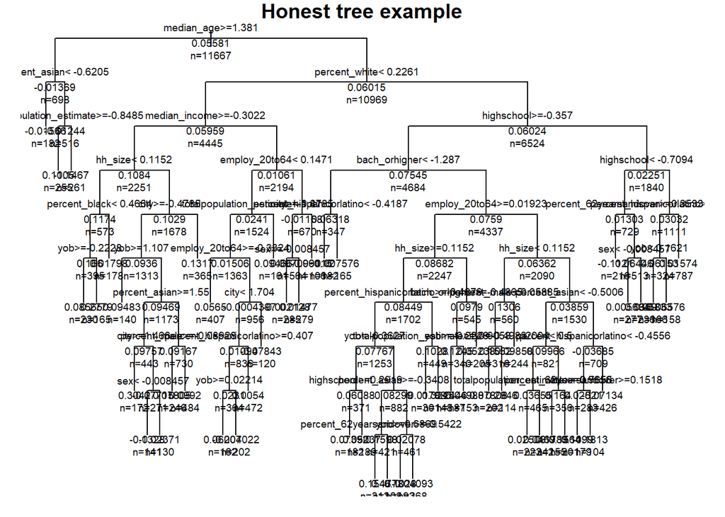

```r
# Predict from honest tree on training
honest_tree_pred_A <- predict(honest_tree_prune, newdata = data_A, type = "vector")

# Predict from honest tree on estimation and
honest_tree_pred_B <- predict(honest_tree_prune, newdata = data_B, type = "vector")
honest_tree_pred_C <- predict(honest_tree_prune, newdata = data_C, type = "vector")

# Plot splits
par(mar = c(1, 1, 1, 1))
plot(honest_tree_prune, uniform = TRUE,
     main = "Honest tree example")
text(honest_tree_prune, use.n = TRUE, all = TRUE, cex=.6)
```

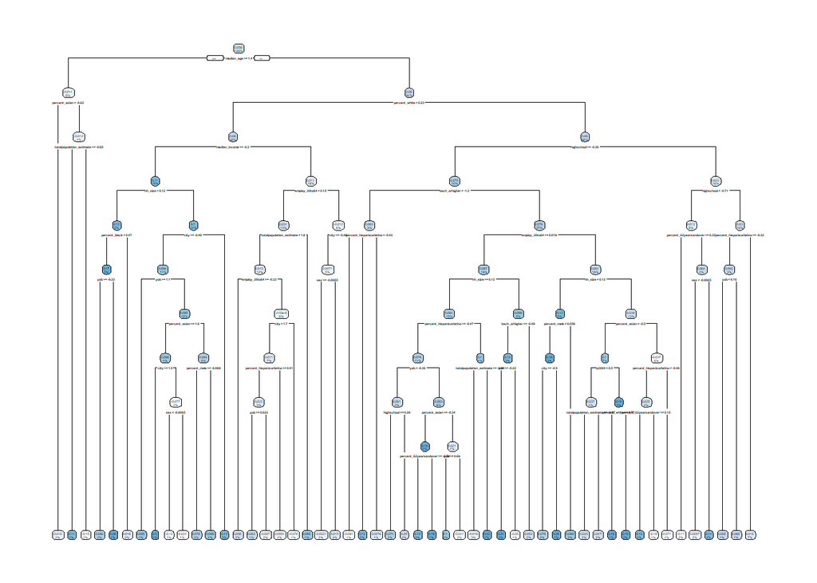

```r
# Or use build-in command

rpart.plot(honest_tree_prune)
```

There are multiple packages for plotting; there is also fancyrpartplot. If the plot is hard to read, you can prune the tree more and re-plot.

```r
dev.off()
```

Next we estimate causal forest using causal.forest from grf package using residualization

We residualize in one command this time by setting *precompute.nuisance* to *TRUE*.

```r
# Settings for Gradient Forest (GS)
# Number of trees grown in the forest
num_trees <- 2000 # make 2000

# The forest will grow ci.group.size trees on each subsample.
ci_size <- 4

# First run regression forests to estimate y(x) = E[Y|X=x] and w(x) = E[W|X=x], and then run a causal forest on the residuals?
pre_comp <- TRUE

# Train gradient forest model
cf_2 <- causal_forest(X = X_A,
                      Y = Y_A,
                      W = W_A,
                      num.trees = num_trees,
                      ci.group.size = ci_size,
                      precompute.nuisance = pre_comp)

# Predict in test data
cf_2_pred_C <- predict(cf_2, newdata = X_C, estimate.variance = TRUE)

# Predict in training data
cf_2_pred_A <- predict(cf_2, newdata = X_A, estimate.variance = TRUE)
```

We make a variance plot.

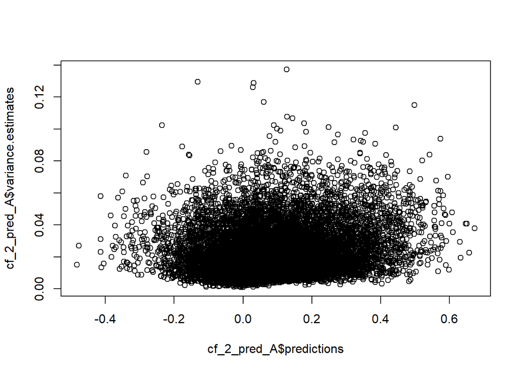

```r
# Variance plot
plot(cf_2_pred_A$predictions, cf_2_pred_A$variance.estimates)
```

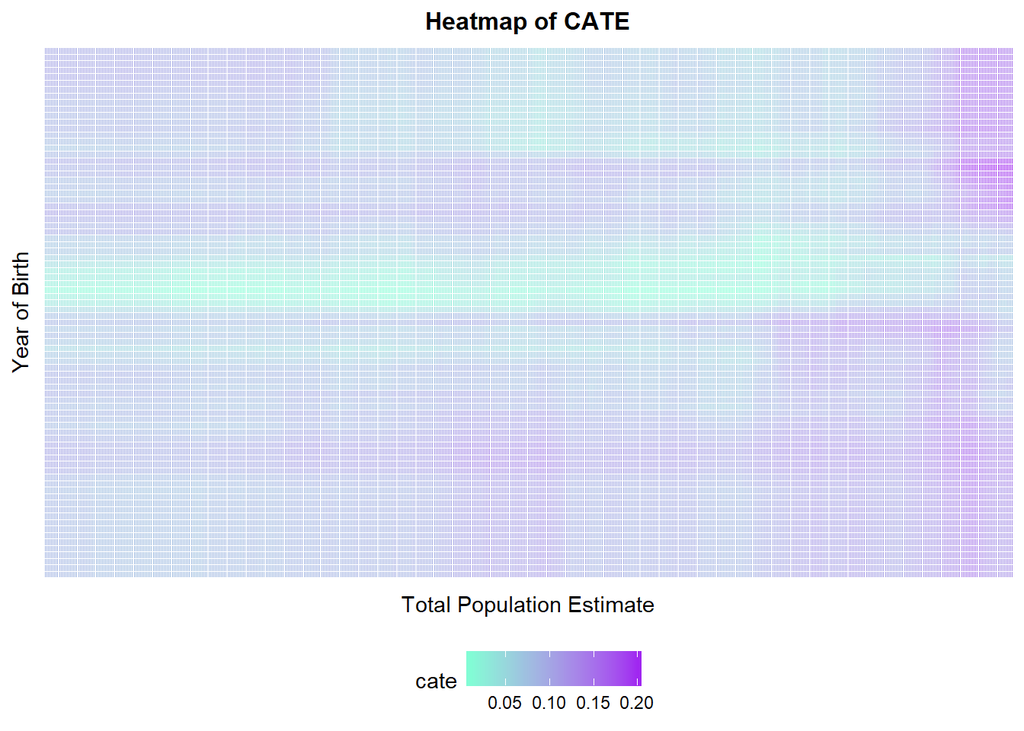

```r
## Visualize the results
# Extract names of both Y, W, and covariates
data_A <- data_A[, !(names(data_A) %in% c("leaf", "Y","W"))]
names_A <- names(data_A)

# Create fake data with original dimensions
train_fake <- as.matrix(data_A)

# Calculate medians in fake data
medians <- apply(X = train_fake, MARGIN = 2, FUN = median)

# Extract unique values of "Year of Birth"
unique_yob <- sort(unique(as.numeric(train_fake[, "yob"])))

# Extract unique values of "Total Population Estimate"
unique_totalpopulation_estimate <- sort(unique(as.numeric(train_fake[, "totalpopulation_estimate"])))

# Expand grid of unique values, i.e. matrix of (length(unique_yob) x length(unique_totalpopulation_estimate)) x 2
unique_val = expand.grid(yob = unique_yob,
                         totalpopulation_estimate = unique_totalpopulation_estimate)

# Create data matrix of medians (large matrix due to the grid expansion)
train_focus <- outer(rep(1, nrow(unique_val)), medians)

# Replace median values of "Year of Birth" by the unique values
train_focus[, "yob"] = unique_val[, "yob"]

# Replace median values of "Total Population Estimate" by the unique values
train_focus[, "totalpopulation_estimate"] = unique_val[, "totalpopulation_estimate"]

# Reformat focus matrix to data frame
train_focus <- data.frame(train_focus)

# Expand grid and format as factor
direct_df <- expand.grid(yob = factor(unique_yob),
                         totalpopulation_estimate = factor(unique_totalpopulation_estimate))

# Predict conditional ATE (CATE)
temp <- predict(cf_2, newdata = train_focus, estimate.variance=FALSE)$predictions
direct_df$cate <- temp

# Construct heatmap using gggplot2
heatmap_plot <- ggplot(data = direct_df, aes(x = totalpopulation_estimate, y = yob)) +
  geom_tile(aes(fill = cate), colour = "white") +
  scale_fill_gradient(low = "aquamarine", high = "purple") +
  labs(title = "Heatmap of CATE",
       x = "Total Population Estimate",
       y = "Year of Birth") +
  theme(legend.position = "bottom",
        plot.title = element_text(hjust = 0.5,
                                  face ="bold",
                                  colour = "black",
                                  size = 12)) +
  theme(axis.line=element_blank(),
        axis.text.x=element_blank(),
        axis.text.y=element_blank(),
        axis.ticks=element_blank())

# Plot heatmap
heatmap_plot
```

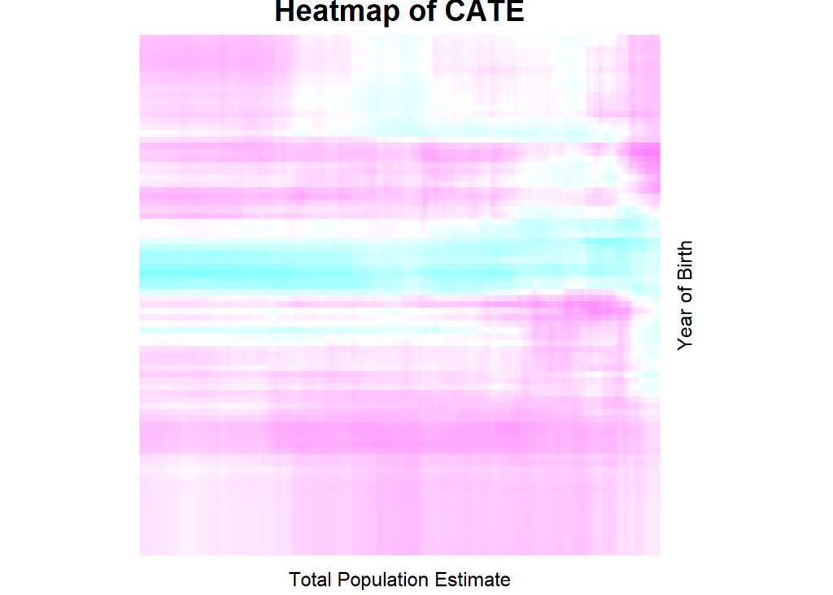

```r
# Create heatmap data for native function heatmap()
heatmap_data <- direct_df

# Order by "Year of Birth" (increasing)
heatmap_data <- heatmap_data[order(heatmap_data$yob), ]

# Reshape data as grid;
# rows corresponds to unique values of "Year of Birth"
# columns corresponds to unique values of "Total Population Estimate"
heatmap_data <- dcast(data = heatmap_data,
                      formula = yob ~ totalpopulation_estimate,
                      fun = mean)

# Remove "Year of Birth" column and format as matrix
heatmap_data <- as.matrix(heatmap_data[, !(names(heatmap_data) %in% c("yob"))])

# Construct and plot heatmap using native function heatmap()
heatmap(x = heatmap_data,
        Rowv = NA,
        Colv = NA,
        scale = "column",
        margins = c(2, 2),
        labRow = FALSE,
        labCol = FALSE,
        xlab = "Total Population Estimate",
        ylab = "Year of Birth",
        main = "Heatmap of CATE",
        col = cm.colors(256))
```

In the code, we demonstrate the options to produce the heat map. The first uses the package *ggplot2*, whereas the second uses the native R function *heatmap()*. As expected, the results are very similar. Both heat maps indicate that the total population effect does not play a central role for the treatment effect due to the lack of horizontal variation. However, the year of birth plays a role, indicated by the vertical variation in colors.

Finally, we compare the results across methods. We address the question, which methods give more heterogeneity? How well do they match heterogeneous treatment effects?

To compare the heterogeneity across methods, we plot the distributions of treatment effects on the same scale.

```
                      mean         sd     median         min       max
lasso           0.06729112 0.01956172 0.06393802  0.02301715 0.0881726
post_selec_ols  0.10375853 0.01838893 0.09298909  0.07280751 0.1266904
honest_tree     0.05297195 0.09931846 0.05238095 -0.18127341 0.3214689
causal_forest_2 0.10393789 0.10938454 0.09865212 -0.40783050 0.6214680
```

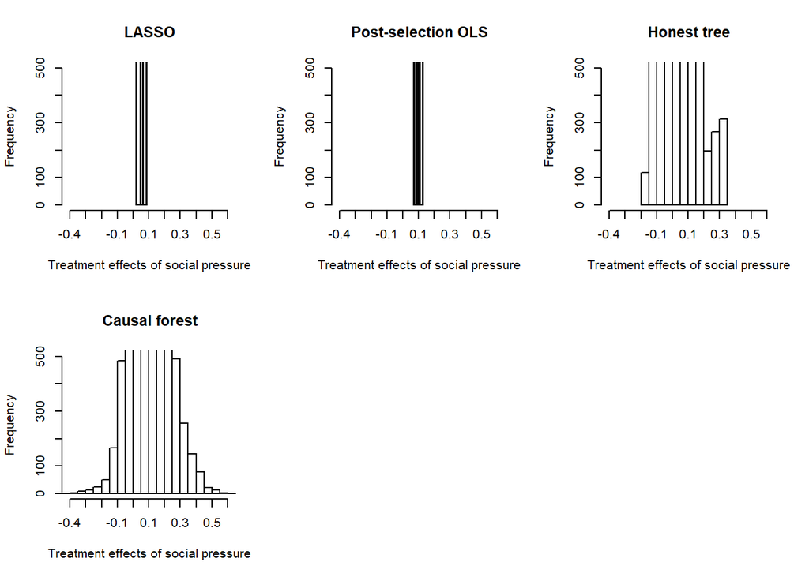

```r
## Compare Heterogeneity
het_effects <- cbind(lasso = c(pred_lasso_C),
                     post_selec_ols = c(pred_post_selec_ols_C),
                     honest_tree = c(honest_tree_pred_C),
                     causal_forest_2 = c(cf_2_pred_C$predictions))

# Set the margins (two rows, three columns)
par(mfrow = c(2, 3))

# Set range of the x-axis
xrange <- range( c(het_effects[, 1], het_effects[, 2], het_effects[, 3], het_effects[, 4]))

# Lasso
hist(het_effects[, 1], main = "LASSO", xlim = xrange, xaxt="n",
     xlab = "Treatment effects of social pressure", ylim=c(0,500))
axis(1, at = round(seq(xrange[1], xrange[2], by=0.1), 1), labels = round(seq(xrange[1], xrange[2], by=0.1), 1) )

# Post-selection OLS
hist(het_effects[, 2], main = "Post-selection OLS", xlim = xrange, xaxt="n",
     xlab = "Treatment effects of social pressure", ylim=c(0,500))
axis(1, at = round(seq(xrange[1], xrange[2], by=0.1), 1), labels = round(seq(xrange[1], xrange[2], by=0.1), 1) )

# Honest tree
hist(het_effects[, 3], main = "Honest tree", xlim = xrange, xaxt="n",
     xlab = "Treatment effects of social pressure", ylim=c(0,500))
axis(1, at = round(seq(xrange[1], xrange[2], by=0.1), 1), labels = round(seq(xrange[1], xrange[2], by=0.1), 1) )

# Causal forest (grf)
hist(het_effects[, 4], main = "Causal forest", xlim = xrange, xaxt="n",
     xlab = "Treatment effects of social pressure", ylim=c(0,500))
axis(1, at = round(seq(xrange[1], xrange[2], by=0.1), 1), labels = round(seq(xrange[1], xrange[2], by=0.1), 1) )

# Summary statistics
summary_stats <- do.call(data.frame,
                         list(mean = apply(het_effects, 2, mean),
                              sd = apply(het_effects, 2, sd),
                              median = apply(het_effects, 2, median),
                              min = apply(het_effects, 2, min),
                              max = apply(het_effects, 2, max)))

summary_stats
```

As apparent from both the plots and the summary statistics, the causal forest from the *grf* package appears to yield most heterogeneity.

Another way to compare the methods is to look at the MSE on a test set using Y_star (the transformed outcome) as a proxy for the true treatment effect. Define Y_star in the test set, and compare the MSE across methods. We do this on the test set, which in our case is the sub-sample C. We use the transformed outcome as a proxy for the true treatment effect.

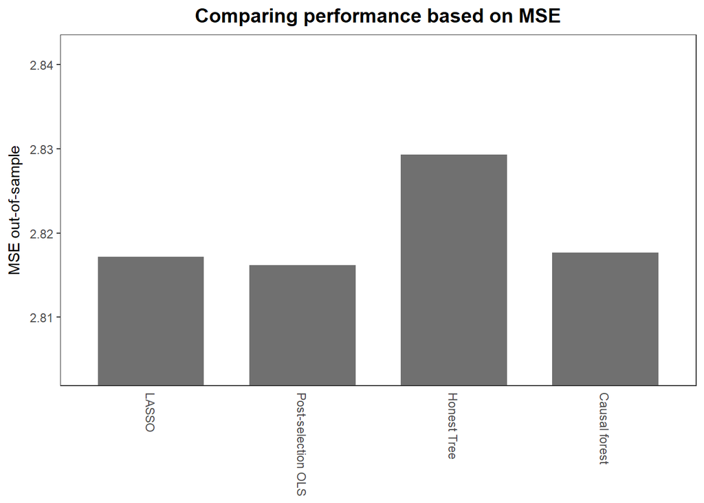

```r
# Construct propensity score from randomized experiment
prop_score <- mean(W_C) # Randomized experiment

# Construct Y_star in test sample
Y_star <- W_C * (Y_C / prop_score) - (1 - W_C) * (Y_C / (1 - prop_score))

## LASSO
# Construct model matrix for sample C
train_C_W0 <- model.matrix(object = linear_het, data = data_C_W0)[, -1]
train_C_W1 <- model.matrix(object = linear_het, data = data_C_W1)[, -1]

# Make predictions for W = 0 and W = 1 using sample C
pred_lasso_C_W0 <- predict(lasso_linear_A, newx = train_C_W0, s = lasso_linear_A$lambda.1se)
pred_lasso_C_W1 <- predict(lasso_linear_A, newx = train_C_W1, s = lasso_linear_A$lambda.1se)

# Compute individual treatment effect
pred_lasso_C <- pred_lasso_C_W1 - pred_lasso_C_W0

# Calculate MSE based on Y_star
MSE_lasso <- mean((Y_star - pred_lasso_C)^2)

## Post selection OLS
# Make predictions for W = 0 and W = 1
pred_ols_W0_C <- predict(post_selec_ols_A, newdata = data_C_W0)
pred_ols_W1_C <- predict(post_selec_ols_A, newdata = data_C_W1)

# Compute individual treatment effect
pred_post_selec_ols_C <- pred_ols_W1_C - pred_ols_W0_C

# Calculate MSE based on Y_star
MSE_post_selec_ols <- mean((Y_star - pred_post_selec_ols_C)^2)

## Honest tree
# Calculate MSE based on Y_star
MSE_honest_tree <- mean((Y_star - honest_tree_pred_C)^2)

## Causal forest (from package grf)
# Calculate MSE based on Y_star
MSE_cf_2 <- mean((Y_star - cf_2_pred_C$predictions)^2)

## MSE
# Create data frame
performance_MSE <- data.frame(matrix(rep(NA, 1), nrow = 1, ncol = 1))
rownames(performance_MSE) <- c("LASSO")
colnames(performance_MSE) <- c("MSE")

# Load in results
performance_MSE["LASSO", "MSE"] <- MSE_lasso
performance_MSE["Post-selection OLS", "MSE"] <- MSE_post_selec_ols
performance_MSE["Honest Tree", "MSE"] <- MSE_honest_tree
performance_MSE["Causal forest", "MSE"] <- MSE_cf_2

# Setting the range
xrange2 <- range(performance_MSE$MSE - 2*sd(performance_MSE$MSE),
                 performance_MSE$MSE,
                 performance_MSE$MSE + 2*sd(performance_MSE$MSE))

# Create plot
MSEplot <- ggplot(performance_MSE) +
  geom_bar(mapping = aes(x = factor(rownames(performance_MSE),
                                    levels = rownames(performance_MSE)),
                         y = MSE),
           stat = "identity", fill = "gray44", width=0.7,
           position = position_dodge(width=0.2)) +
  theme_bw() +
  coord_cartesian(ylim=c(xrange2[1], xrange2[2])) +
  theme(axis.ticks.x = element_blank(), axis.title.x = element_blank(),
        panel.grid.major = element_blank(), panel.grid.minor = element_blank(),
        plot.background = element_blank(),
        axis.text.x = element_text(angle = -90, hjust = 0, vjust = 0.5)) +
  ylab("MSE out-of-sample") +
  ggtitle("Comparing performance based on MSE") +
  theme(plot.title = element_text(hjust = 0.5, face ="bold",
                                  colour = "black", size = 14))

# Plot
MSEplot
```

We should also add error bars to these in future versions.

There are many other exercises to do for CATE’s, including testing differences in characteristics for high and low treatment effect groups, and looking at partial effects, e.g. what is the effect of one covariate holding others constant. The fully nonparametric models like causal forest are appropriate for that exercise, while the models that choose simpler representations like LASSO and CausalTree are not appropriate because they don’t attempt to control for all covariates.

```r
# Stop timer
proc.time() - ptm
```

```
   user  system elapsed
2488.58   45.44 1153.37
```